# numpy

# 2.8 数组的排序

这一节将介绍用于排序 NumPy 数组的相关算法.

插入排序、 选择排序、 归并排序、 快速排序、 冒泡 排序等

例如，一个简单的选择排序重复寻找列表中的最小值，并且不断交换直到列表是有序的

```python
import numpy as np
def selection_sort(x):
    for i in range(len(x)):
        swap = i + np.argmin(x[i:])
        (x[i], x[swap]) = (x[swap], x[i])
    return x
```

```python
x = np.array([2, 1, 4, 3, 5])
selection_sort(x)
```

```
array([1, 2, 3, 4, 5])
```

“大 O 标记”常用来标示算法的复杂度（详情 请参见 2.8.3 节），选择排序的平均算法复杂度为 [N 2]：如果你将列表中元素的个数翻倍， 那么运行时间就会延长 4 倍。

```python
# 即便如此，选择排序都比我自己最喜欢的 bogosort 排序算法的性能要好：
def bogosort(x):
    while np.any(x[:-1] > x[1:]):
        np.random.shuffle(x)
    return x
```

```python
x = np.array([2, 1, 4, 3, 5])
bogosort(x)
```

```
array([1, 2, 3, 4, 5])
```

这个很傻的算法的实现完全是碰运气：它不断对数组元素进行随机重排，直到成为有序数 组才停止。这个算法的复杂度为 [N × N !]（N 乘以 N 的阶乘）。很明显，这种方法是永 远不会用于任何实际运算场景的

幸运的是， Python 包含的很多内置排序算法都比上面例子中的算法高效得多。首先介 绍 Python 的内置排序算法，然后介绍 NumPy 中的排序算法和优化过的 NumPy 数组排 序算法

## 2.8.1 NumPy中的快速排序： np.sort和np.argsort

尽管 Python 有内置的 sort 和 sorted 函数可以对列表进行排序，但是这里不会介绍这两个 函数，因为 NumPy 的 np.sort 函数实际上效率更高。默认情况下， np.sort 的排序算法是 快速排序，其算法复杂度为 [N log N ]，另外也可以选择归并排序和堆排序。对于大多数 应用场景，默认的快速排序已经足够高效了。

如果想在不修改原始输入数组的基础上返回一个排好序的数组，可以使用 np.sort：

```python
x = np.array([2, 1, 4, 3, 5])
np.sort(x)
```

```
array([1, 2, 3, 4, 5])
```

如果希望用排好序的数组替代原始数组，可以使用数组的 sort 方法：

```python
x.sort()
print(x)
```

```
[1 2 3 4 5]
```

另外一个相关的函数是 argsort，该函数返回的是原始数组排好序的索引值：

```python
 x = np.array([2, 1, 4, 3, 5])
i = np.argsort(x)
print(i)
```

```
[1 0 3 2 4]
```

这些索引值可以被用于（通过花哨的索引）创建有序的数组：

```python
x[i]
```

```
array([1, 2, 3, 4, 5])
```

沿着行或列排序

NumPy 排序算法的一个有用的功能是通过 axis 参数，沿着多维数组的行或列进行排序

```python
rand = np.random.RandomState(42)
X = rand.randint(0, 10, (4, 6))
print(X)
```

```
[[6 3 7 4 6 9]
 [2 6 7 4 3 7]
 [7 2 5 4 1 7]
 [5 1 4 0 9 5]]
```

```python
# 对X的每一列排序
np.sort(X, axis=0)
```

```
array([[2, 1, 4, 0, 1, 5],
       [5, 2, 5, 4, 3, 7],
       [6, 3, 7, 4, 6, 7],
       [7, 6, 7, 4, 9, 9]])
```

```python
# 对X每一行排序
np.sort(X, axis=1)
```

```
array([[3, 4, 6, 6, 7, 9],
       [2, 3, 4, 6, 7, 7],
       [1, 2, 4, 5, 7, 7],
       [0, 1, 4, 5, 5, 9]])
```

## 2.8.2 部分排序： 分隔

有时候我们不希望对整个数组进行排序，仅仅希望找到数组中第 K 小的值， NumPy 的 np.partition 函数提供了该功能。 np.partition 函数的输入是数组和数字 K，输出结果是 一个新数组，最左边是第 K 小的值，往右是任意顺序的其他值：

```python
x = np.array([7, 2, 3, 1, 6, 5, 4])
np.partition(x, 3)
```

```
array([2, 1, 3, 4, 6, 5, 7])
```

请注意，结果数组中前三个值是数组中最小的三个值，剩下的位置是原始数组剩下的值。 在这两个分隔区间中，元素都是任意排列的

与排序类似，也可以沿着多维数组任意的轴进行分隔：

```python
np.partition(X, 2, axis=1)
```

```
array([[3, 4, 6, 7, 6, 9],
       [2, 3, 4, 7, 6, 7],
       [1, 2, 4, 5, 7, 7],
       [0, 1, 4, 5, 9, 5]])
```

输出结果是一个数组，该数组每一行的前两个元素是该行最小的两个值，每行的其他值分 布在剩下的位置。

## 2.8.3 示例： K个最近邻

以下示例展示的是如何利用 argsort 函数沿着多个轴快速找到集合中每个点的最近邻

```python
# 首先，在二维平面上创建一个有 10 个随机点的集合。按照惯例，将这些数据点放在一个 10× 2 的数组中：
X = rand.rand(10, 2)
```

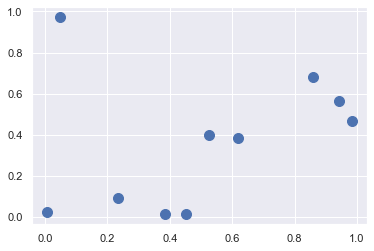

```python
# 为了对这些点有一个直观的印象，来画出它的散点图
%matplotlib inline
import matplotlib.pyplot as plt
import seaborn; seaborn.set() # 设置画图风格
plt.scatter(X[:, 0], X[:, 1], s=100);
```

```python
# 现在来计算两两数据点对间的距离。我们学过两点间距离的平方等于每个维度的距离差的平方的和。
# 利用 NumPy 的广播（详情请参见 2.5 节）和聚合（详情请参见 2.4 节）功能，可以用一行代码计算矩阵的平方距离：
dist_sq = np.sum((X[:,np.newaxis,:] - X[np.newaxis,:,:]) ** 2, axis=-1)
```

```python
X[:,np.newaxis,:]  # （10,1，2）
```

```
array([[[0.00706631, 0.02306243]],

       [[0.52477466, 0.39986097]],

       [[0.04666566, 0.97375552]],

       [[0.23277134, 0.09060643]],

       [[0.61838601, 0.38246199]],

       [[0.98323089, 0.46676289]],

       [[0.85994041, 0.68030754]],

       [[0.45049925, 0.01326496]],

       [[0.94220176, 0.56328822]],

       [[0.3854165 , 0.01596625]]])
```

```python
X
```

```
array([[0.00706631, 0.02306243],
       [0.52477466, 0.39986097],
       [0.04666566, 0.97375552],
       [0.23277134, 0.09060643],
       [0.61838601, 0.38246199],
       [0.98323089, 0.46676289],
       [0.85994041, 0.68030754],
       [0.45049925, 0.01326496],
       [0.94220176, 0.56328822],
       [0.3854165 , 0.01596625]])
```

```python
X[np.newaxis,:,:] # （1,10,2）
```

```
array([[[0.00706631, 0.02306243],
        [0.52477466, 0.39986097],
        [0.04666566, 0.97375552],
        [0.23277134, 0.09060643],
        [0.61838601, 0.38246199],
        [0.98323089, 0.46676289],
        [0.85994041, 0.68030754],
        [0.45049925, 0.01326496],
        [0.94220176, 0.56328822],
        [0.3854165 , 0.01596625]]])
```

```python
# （10,10,2）
```

```python
# 在坐标系中计算每对点的差值
differences = X[:, np.newaxis, :] - X[np.newaxis, :, :]
differences.shape
```

```
(10, 10, 2)
```

```python
# 求出差值的平方
sq_differences = differences ** 2
sq_differences.shape
```

```
(10, 10, 2)
```

```python
# 将差值求和获得平方距离
dist_sq = sq_differences.sum(-1)   # 维度
dist_sq.shape
```

```
(10, 10)
```

```python
# 请再次确认以上步骤，应该看到该矩阵的对角线（也就是每个点到其自身的距离）的值都是 0：
dist_sq.diagonal()
```

```
array([0., 0., 0., 0., 0., 0., 0., 0., 0., 0.])
```

```python
# 当我们有了这样一个转化为两点间的平方距离的矩阵后，就可以使用np.argsort 函数沿着每行进行排序了。最左边的列给出的索引值就是最近邻：
nearest = np.argsort(dist_sq, axis=1)
print(nearest)
```

```
[[0 3 9 7 1 4 2 5 6 8]
 [1 4 7 9 3 6 8 5 0 2]
 [2 1 4 6 3 0 8 9 7 5]
 [3 9 7 0 1 4 5 8 6 2]
 [4 1 8 5 6 7 9 3 0 2]
 [5 8 6 4 1 7 9 3 2 0]
 [6 8 5 4 1 7 9 3 2 0]
 [7 9 3 1 4 0 5 8 6 2]
 [8 5 6 4 1 7 9 3 2 0]
 [9 7 3 0 1 4 5 8 6 2]]
```

```python
# 需要注意的是，第一列是按 0~9 从小到大排列的。这是因为每个点的最近邻是其自身，所以结果也正如我们所想。
```

```python
# 如果使用全排序，我们实际上可以实现的比这个例子展示的更多。
# 如果我们仅仅关心 k 个最近邻，那么唯一需要做的是分隔每一行，这样最小的 k + 1 的平方距离将排在最前面，其他更长的距离占据矩阵该行的其他位置。
# 可以用 np.argpartition 函数实现：
K = 2
nearest_partition = np.argpartition(dist_sq, K + 1, axis=1)
```

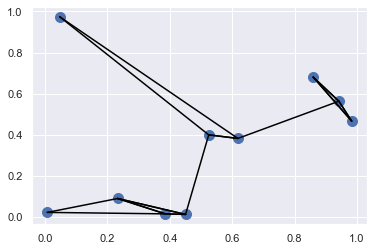

```python
# 为了将邻节点网络可视化，我们将每个点和其最近的两个最近邻连接
plt.scatter(X[:, 0], X[:, 1], s=100)
# 将每个点与它的两个最近邻连接
K = 2
for i in range(X.shape[0]):
    for j in nearest_partition[i, :K+1]:
        # 画一条从X[i]到X[j]的线段
        # 用zip方法实现：
        plt.plot(*zip(X[j], X[i]), color='black')
```

如果不用太严谨的眼光看待大 O 标记，那么它其实是告诉你：随着输入数据量的增 长，你的算法将花费多少时间

# 2.9 结构化数据： NumPy的结构化数组

本节介绍 NumPy 的结构化数组和记录数组，它们为复合的、异构的数据提供了非常有 效的存储。

尽管这里列举的模式对于简单的操作非常有用，但是这些场景通常也可以用 Pandas 的 DataFrame 来实现

```python
# 假定现在有关于一些人的分类数据（如姓名、年龄和体重），我们需要存储这些数据用于Python 项目，那么一种可行的方法是将它们存在三个单独的数组中：
name = ['Alice', 'Bob', 'Cathy', 'Doug']
age = [25, 45, 37, 19]
weight = [55.0, 85.5, 68.0, 61.5]
```

但是这种方法有点笨，因为并没有任何信息告诉我们这三个数组是相关联的。

NumPy 可以用结构化数组实现这 种存储，这些结构化数组是复合数据类型的。

```python
x = np.zeros(4, dtype=int)
```

与之类似，通过指定复合数据类型，可以构造一个结构化数组：

```python
 # 使用复合数据结构的结构化数组
data = np.zeros(4, dtype={'names':('name', 'age', 'weight'),
'formats':('U10', 'i4', 'f8')})
print(data.dtype)
```

```
[('name', '<U10'), ('age', '<i4'), ('weight', '<f8')]
```

```python
data = np.zeros(4, dtype={'names':['name', 'age', 'weight'],
'formats':['U10', 'i4', 'f8']})
print(data.dtype)
```

```
[('name', '<U10'), ('age', '<i4'), ('weight', '<f8')]
```

这里 U10 表示“长度不超过 10 的 Unicode 字符串”， i4 表示“4 字节（即 32 比特）整型”， f8 表示“8 字节（即 64 比特）浮点型”。后续的小节中将介绍更多的数据类型代码。

```python
data['name'] = name
data['age'] = age
data['weight'] = weight
print(data)
```

```
[('Alice', 25, 55. ) ('Bob', 45, 85.5) ('Cathy', 37, 68. )
 ('Doug', 19, 61.5)]
```

结构化数组的方便之处在于，你可以通过索引或名称查看相应的值：

```python
# 获取所有名字
data['name']
```

```
array(['Alice', 'Bob', 'Cathy', 'Doug'], dtype='<U10')
```

```python
# 获取数据第一行
data[0]
```

```
('Alice', 25, 55.)
```

```python
# 获取最后一行的名字
data[-1]['name']
```

```
'Doug'
```

利用布尔掩码，还可以做一些更复杂的操作，如按照年龄进行筛选：

```python
# 获取年龄小于30岁的人的名字
data[data['age'] < 30]['name']
```

```
array(['Alice', 'Doug'], dtype='<U10')
```

请注意，如果你希望实现比上面更复杂的操作，那么你应该考虑使用 Pandas 包，

## 2.9.1 生成结构化数组

结构化数组的数据类型有多种制定方式。此前我们看过了采用字典的方法：

```python
np.dtype({'names':('name', 'age', 'weight'),
'formats':('U10', 'i4', 'f8')})
```

```
dtype([('name', '<U10'), ('age', '<i4'), ('weight', '<f8')])
```

为了简明起见，数值数据类型可以用 Python 类型或 NumPy 的 dtype 类型指定

```python
np.dtype({'names':('name', 'age', 'weight'),
'formats':((np.str_, 10), int, np.float32)})
```

```
dtype([('name', '<U10'), ('age', '<i4'), ('weight', '<f4')])
```

复合类型也可以是元组列表：

```python
np.dtype([('name', 'S10'), ('age', 'i4'), ('weight', 'f8')])
```

```
dtype([('name', 'S10'), ('age', '<i4'), ('weight', '<f8')])
```

如果类型的名称对你来说并不重要，那你可以仅仅用一个字符串来指定它。在该字符串中 数据类型用逗号分隔：

```python
np.dtype('S10,i4,f8')
```

```
dtype([('f0', 'S10'), ('f1', '<i4'), ('f2', '<f8')])
```

简写的字符串格式的代码可能看起来令人困惑，但是它们其实基于非常简单的规则。第 一个（可选）字符是 < 或者 >，分别表示“低字节序”（little endian）和“高字节序”（bid endian），表示字节（bytes）类型的数据在内存中存放顺序的习惯用法。后一个字符指定的 是数据的类型：字符、字节、整型、浮点型，等等（如表 2-4 所示）。最后一个字符表示该 对象的字节大小。

[figure not shown]

## 2.9.2 更高级的复合类型

NumPy 中也可以定义更高级的复合数据类型。例如，你可以创建一种类型，其中每个元素 都包含一个数组或矩阵。我们会创建一个数据类型，该数据类型用 mat 组件包含一个 3× 3 的浮点矩阵：

```python
tp = np.dtype([('id', 'i8'), ('mat', 'f8', (3, 3))])
X = np.zeros(1, dtype=tp)
print(X[0])
print(X['mat'][0])
```

```
(0, [[0., 0., 0.], [0., 0., 0.], [0., 0., 0.]])
[[0. 0. 0.]
 [0. 0. 0.]
 [0. 0. 0.]]
```

```python
X
```

```
array([(0, [[0., 0., 0.], [0., 0., 0.], [0., 0., 0.]])],
      dtype=[('id', '<i8'), ('mat', '<f8', (3, 3))])
```

```python
X['mat']
```

```
array([[[0., 0., 0.],
        [0., 0., 0.],
        [0., 0., 0.]]])
```

```python
np.size(X['mat'])
```

```
9
```

```python
np.shape(X['mat'])
```

```
(1, 3, 3)
```

## 2.9.3 记录数组： 结构化数组的扭转

NumPy 还提供了 np.recarray 类。它和前面介绍的结构化数组几乎相同，但是它有一个独 特的特征：域可以像属性一样获取，而不是像字典的键那样获取。前面的例子通过以下代 码获取年龄：

```python
data['age']
```

```
array([25, 45, 37, 19])
```

如果将这些数据当作一个记录数组，我们可以用很少的按键来获取这个结果：

```python
data_rec = data.view(np.recarray)
data_rec.age
```

```
array([25, 45, 37, 19])
```

记录数组的不好的地方在于，即使使用同样的语法，在获取域时也会有一些额外的开销， 如以下示例所示

```python
%timeit data['age']
%timeit data_rec['age']
%timeit data_rec.age
```

```
72.8 ns ± 0.963 ns per loop (mean ± std. dev. of 7 runs, 10,000,000 loops each)
1.4 µs ± 13.4 ns per loop (mean ± std. dev. of 7 runs, 1,000,000 loops each)
1.95 µs ± 31.8 ns per loop (mean ± std. dev. of 7 runs, 1,000,000 loops each)
```

## 2.9.4 关于Pandas

本章将结构化数组和记录数组放在末尾是有意为之，因为它们能很好地衔接下一章要介绍 的包： Pandas。本章介绍的结构化数组在某些场景中很好用，特别是当你用 C、 Fortran 或 其他语言将 NumPy 数组映射为二进制数据格式时。但是如果每天都需要使用结构化数据， 那么 Pandas 包是更好的选择，我们将在接下来的一章详细介绍它。